# Practical Machine Learning Course Project

Andreas von Ballmoos

April 20, 2015

# Introduction

This is the document for the course project of Coursera/JHU’s course “Practical Machine Learning” in April 2015.

The project takes place in the quantified self movement. The data for this project has been generously provided by http://groupware.les.inf.puc-rio.br/har. They are the result of a study of correctly and incorrectly performed weight lifts. Our goal is to use the data to predict the manner (class) in which the participants did the exercise:

- exactly according to the specification (Class A)
- throwing the elbows to the front (Class B)
- lifting the dumbbell only halfway (Class C)
- lowering the dumbbell only halfway (Class D)
- throwing the hips to the front (Class E)

Source: http://groupware.les.inf.puc-rio.br/public/papers/2013.Velloso.QAR-WLE.pdf

# Prerequisits

Load the needed R libraries & set a seed to be reproducible:

```r
library(caret)
library(rpart)
library(rattle)
library(randomForest)
set.seed(20150422)
```

# Getting and cleaning the data

```r
trainDataUrl = "http://d396qusza40orc.cloudfront.net/predmachlearn/pml-training.csv"
testDataUrl ="http://d396qusza40orc.cloudfront.net/predmachlearn/pml-testing.csv"

# download
trainSet <- read.csv(trainDataUrl, na.strings=c("NA","#DIV/0!","")) #19622 cases, class in the last column
testSet <- read.csv(testDataUrl, na.strings=c("NA","#DIV/0!","")) #20 cases, problem_id in the last column

# cleaning data 1: remove columns from training and test set that have more than 90% NAs in the training set, http://stackoverflow.com/questions/15968494/how-to-delete-columns-with-na-in-r
trainSet2 <- trainSet[, colSums(is.na(trainSet)) < nrow(trainSet) * 0.9]
testSet2 <- testSet[, colSums(is.na(trainSet)) < nrow(trainSet) * 0.9]

#cleaning data 2: remove the first seven columns (name, time,...) - they are no useful measurements
trainSet3 <- trainSet2[, -c(1:7)]
testSet3 <- testSet2[, -c(1:7)]

summary(trainSet3$classe)
```

```
##    A    B    C    D    E
## 5580 3797 3422 3216 3607
```

# Creating the training and test sets

```r
inTrain <- createDataPartition(y=trainSet3$classe,p=0.7, list=FALSE)
training <- trainSet3[inTrain,]
testing <- trainSet3[-inTrain,]
```

# Building the model

## Decision tree

Build the model:

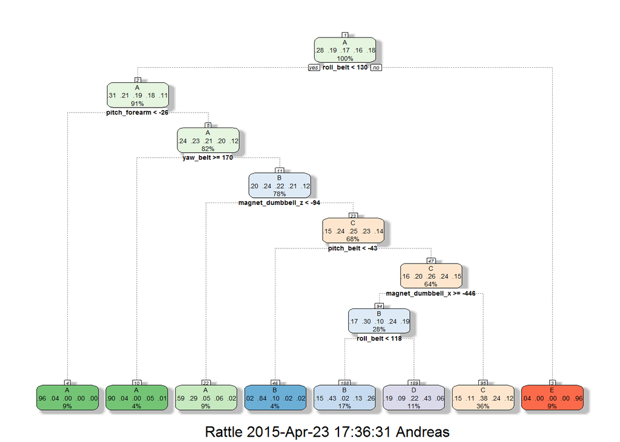

```r
modFit <- train(classe ~ .,method="rpart",data=training)
fancyRpartPlot(modFit$finalModel)
```

Predict the testing result:

```r
testprediction <- predict(modFit, newdata=testing)
confusionMatrix(testprediction, testing$classe)
```

```
## Confusion Matrix and Statistics
##
##           Reference
## Prediction    A    B    C    D    E
##          A 1034  207   27   48   16
##          B  188  634   41  144  239
##          C  298  241  825  508  267
##          D  127   57  133  264   45
##          E   27    0    0    0  515
##
## Overall Statistics
##
##                Accuracy : 0.556
##                  95% CI : (0.5432, 0.5687)
##     No Information Rate : 0.2845
##     P-Value [Acc > NIR] : < 2.2e-16
##
##                   Kappa : 0.4428
##  Mcnemar's Test P-Value : < 2.2e-16
##
## Statistics by Class:
##
##                      Class: A Class: B Class: C Class: D Class: E
## Sensitivity            0.6177   0.5566   0.8041  0.27386  0.47597
## Specificity            0.9292   0.8710   0.7296  0.92644  0.99438
## Pos Pred Value         0.7763   0.5088   0.3857  0.42173  0.95018
## Neg Pred Value         0.8594   0.8911   0.9463  0.86689  0.89388
## Prevalence             0.2845   0.1935   0.1743  0.16381  0.18386
## Detection Rate         0.1757   0.1077   0.1402  0.04486  0.08751
## Detection Prevalence   0.2263   0.2117   0.3635  0.10637  0.09210
## Balanced Accuracy      0.7735   0.7138   0.7668  0.60015  0.73517
```

```r
modFit$finalModel
```

```
## n= 13737
##
## node), split, n, loss, yval, (yprob)
##       * denotes terminal node
##
##   1) root 13737 9831 A (0.28 0.19 0.17 0.16 0.18)
##     2) roll_belt< 129.5 12506 8647 A (0.31 0.21 0.19 0.18 0.11)
##       4) pitch_forearm< -26.45 1233   50 A (0.96 0.041 0 0 0) *
##       5) pitch_forearm>=-26.45 11273 8597 A (0.24 0.23 0.21 0.2 0.12)
##        10) yaw_belt>=169.5 574   57 A (0.9 0.042 0 0.049 0.0087) *
##        11) yaw_belt< 169.5 10699 8115 B (0.2 0.24 0.22 0.21 0.12)
##          22) magnet_dumbbell_z< -93.5 1301  537 A (0.59 0.29 0.048 0.058 0.02) *
##          23) magnet_dumbbell_z>=-93.5 9398 7064 C (0.15 0.24 0.25 0.23 0.14)
##            46) pitch_belt< -42.95 575   92 B (0.019 0.84 0.097 0.021 0.023) *
##            47) pitch_belt>=-42.95 8823 6545 C (0.16 0.2 0.26 0.24 0.15)
##              94) magnet_dumbbell_x>=-446.5 3866 2694 B (0.17 0.3 0.1 0.24 0.19)
##               188) roll_belt< 117.5 2399 1357 B (0.15 0.43 0.024 0.13 0.26) *
##               189) roll_belt>=117.5 1467  831 D (0.19 0.089 0.22 0.43 0.064) *
##              95) magnet_dumbbell_x< -446.5 4957 3064 C (0.15 0.11 0.38 0.24 0.12) *
##     3) roll_belt>=129.5 1231   47 E (0.038 0 0 0 0.96) *
```

## Random forest

Build the model:

```r
modFit2 <- train(classe ~ .,method="rf",data=training)
```

Predict the testing result:

```r
testprediction2 <- predict(modFit2, newdata=testing)
confusionMatrix(testprediction2, testing$classe)
```

```
## Confusion Matrix and Statistics
##
##           Reference
## Prediction    A    B    C    D    E
##          A 1672    9    0    0    0
##          B    2 1130    2    1    0
##          C    0    0 1021   10    2
##          D    0    0    3  951    8
##          E    0    0    0    2 1072
##
## Overall Statistics
##
##                Accuracy : 0.9934
##                  95% CI : (0.991, 0.9953)
##     No Information Rate : 0.2845
##     P-Value [Acc > NIR] : < 2.2e-16
##
##                   Kappa : 0.9916
##  Mcnemar's Test P-Value : NA
##
## Statistics by Class:
##
##                      Class: A Class: B Class: C Class: D Class: E
## Sensitivity            0.9988   0.9921   0.9951   0.9865   0.9908
## Specificity            0.9979   0.9989   0.9975   0.9978   0.9996
## Pos Pred Value         0.9946   0.9956   0.9884   0.9886   0.9981
## Neg Pred Value         0.9995   0.9981   0.9990   0.9974   0.9979
## Prevalence             0.2845   0.1935   0.1743   0.1638   0.1839
## Detection Rate         0.2841   0.1920   0.1735   0.1616   0.1822
## Detection Prevalence   0.2856   0.1929   0.1755   0.1635   0.1825
## Balanced Accuracy      0.9983   0.9955   0.9963   0.9921   0.9952
```

```r
modFit2$finalModel
```

```
##
## Call:
##  randomForest(x = x, y = y, mtry = param$mtry)
##                Type of random forest: classification
##                      Number of trees: 500
## No. of variables tried at each split: 27
##
##         OOB estimate of  error rate: 0.71%
## Confusion matrix:
##      A    B    C    D    E class.error
## A 3902    3    0    0    1 0.001024066
## B   28 2622    8    0    0 0.013544018
## C    0   14 2374    8    0 0.009181970
## D    0    0   21 2230    1 0.009769094
## E    0    2    3    8 2512 0.005148515
```

## Estimated out of sample error of the models

The estimated out of sample error is (1- accuracy), which is 44.4% for the decision tree and 0.7% for the random forest.

## Model decision

I decide to go to the submission with the Random Forest model , because it

- has a much higher accuracy
- has built-in cross validation, so there’s no further work to meet this course project requirement (see http://www.stat.berkeley.edu/~breiman/RandomForests/cc_home.htm#ooberr “The out-of-bag (oob) error estimate”)
- shows a stable result set for the predictions to be submitted with various seeds - I tried a few different values for set.seed()

# Predict the values to be submitted

```r
submitprediction <- predict(modFit2, testSet3)
```

# Write the files for the submission

```r
pml_write_files = function(x){
  n = length(x)
  for(i in 1:n){
    filename = paste0("problem_id_",i,".txt")
    write.table(x[i],file=filename,quote=FALSE,row.names=FALSE,col.names=FALSE)
  }
}
pml_write_files(submitprediction)
```